# Guía de uso App Science Journal

Edimer David Jaramillo

Febrero de 2019

# 1 Instalar la App Science Journal

[figure not shown]

# 2 Abrir App en su celular

[figure not shown]

# 3 Nuevo experimento

- Clic en el símbolo **+** para generar un nuevo experimento.

# 4 Nombrar nuevo experimento

- Aparecerá un nuevo experimento sin ninguna medición u observacion.

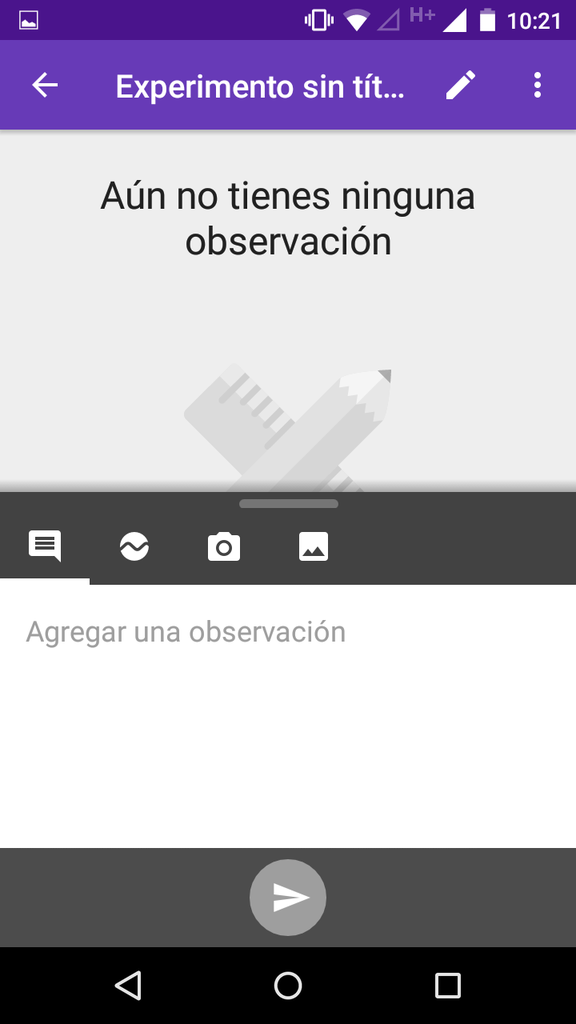

- Edite el nombre de la medición haciendo clic en el lápiz contiguo al texto *Experimento sin título*.
- Actualice el nombre de su experimento (en este caso lleva el nombre de **“Prueba”**)

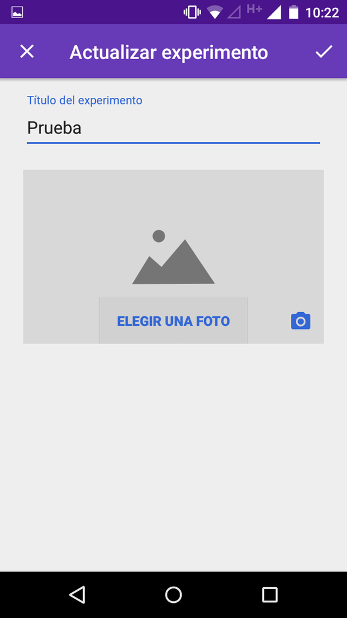

- Después de editar el nombre, tendrá algo similar a la siguiente imagen:

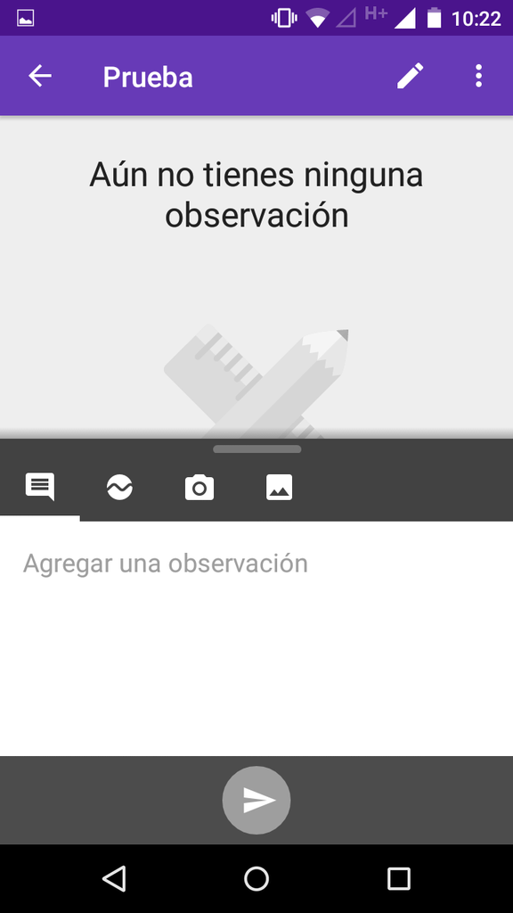

# 5 Mediciones de sonido

- Clic en el siguiente icono:
- Podrá observar todas las opciones de medición con su celular

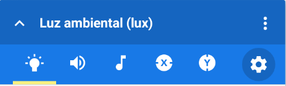

- Elegir la opción de intensidad sonora (dB)
- Clic en el círculo rojo para empezar a medir

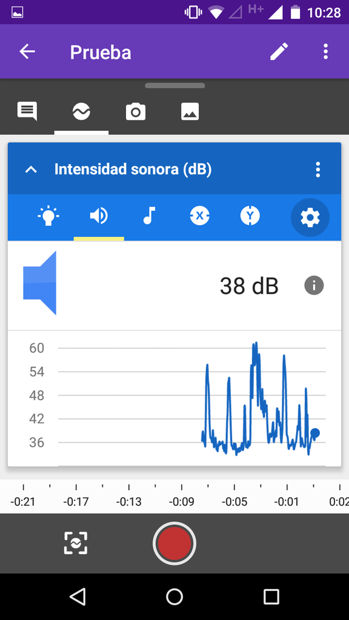

- Al dar clic en el círculo rojo, la App comenzará a registrar mediciones y le mostrará un gráfico en tiempo real.

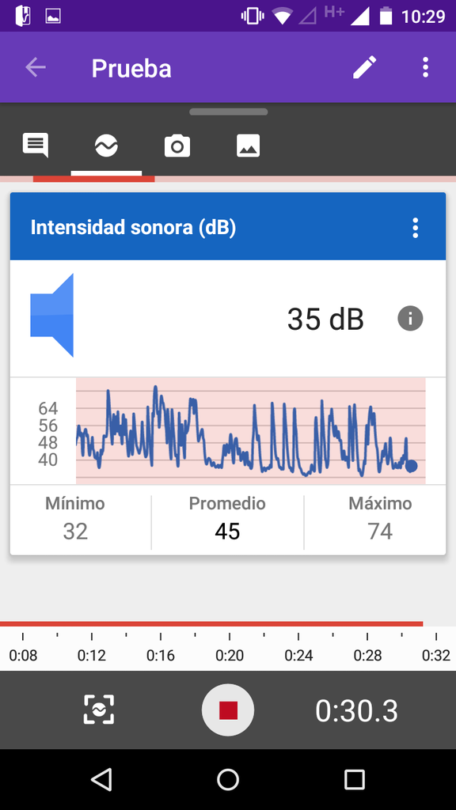

- Clic en el cuadro rojo para detener las mediciones
- Cuando las mediciones se detienen, automáticamente se guarda el experimento con el nombre asignado (*“Prueba”*) y proporciona algunos estadísticos descriptivos como la media, mínimo y máximo.

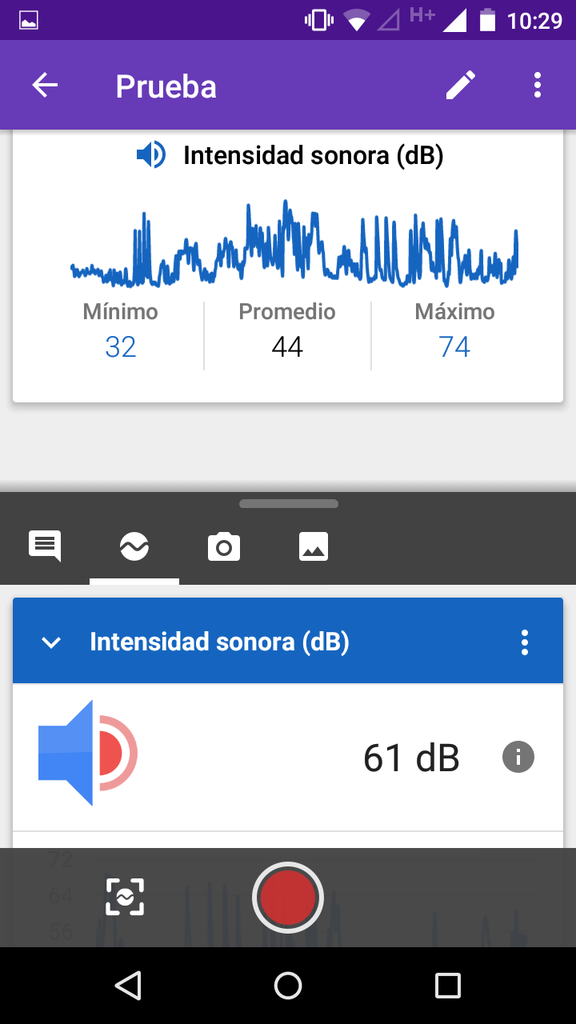

# 6 Compartir datos en *.csv*

- Ingrese a las mediciones que acaba de tomar dando clic encima del experimento en curso.

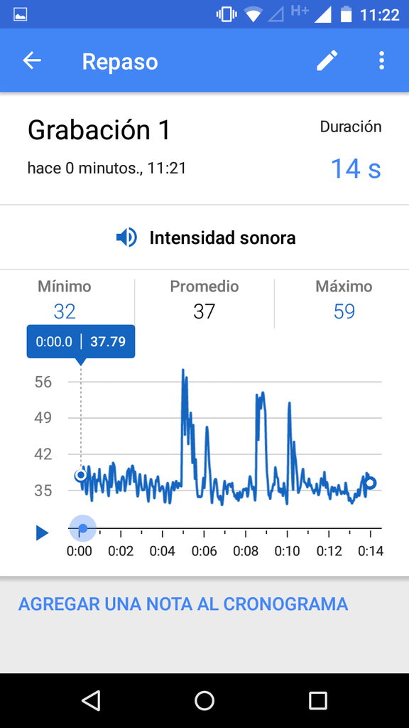

- Clic en los tres puntos de la parte superior derecha
- Clic en **Compartir**

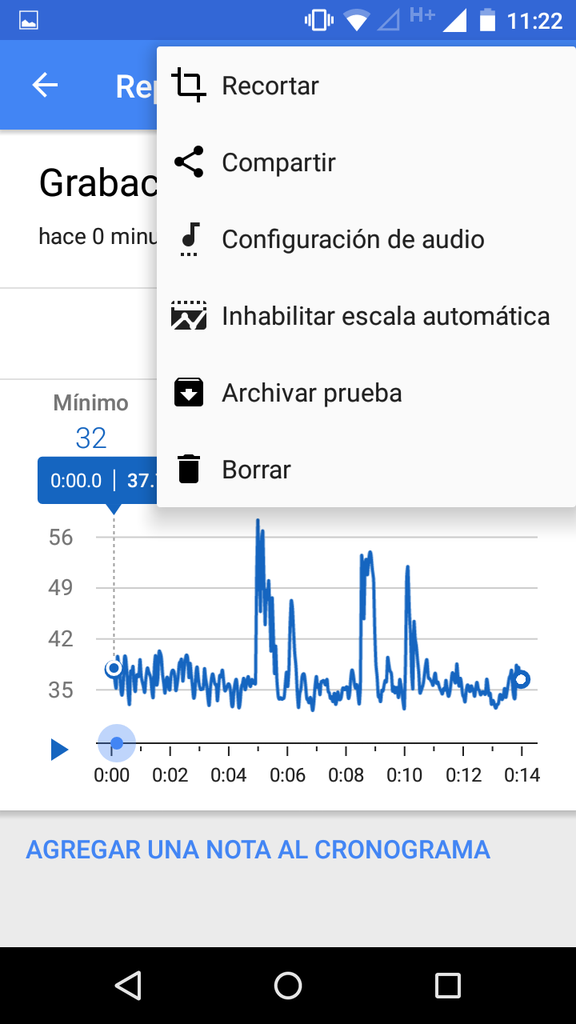

- Aparecerá un cuadro de diálogo en la parte inferior, en el cual deberá dar clic sobre compartir

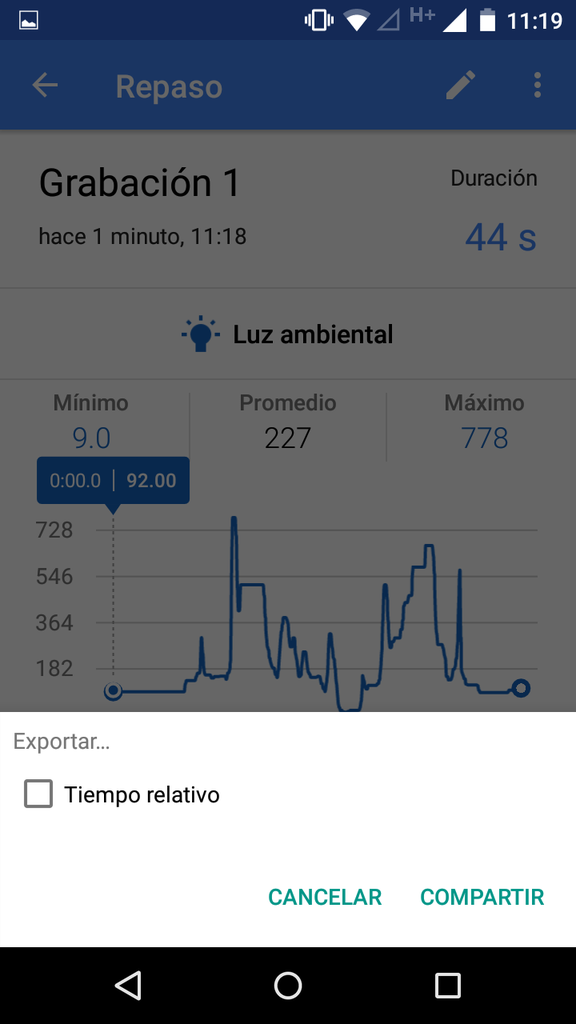

- Elegir la opción “Gmail” para enviar datos en formato *.csv* a un correo electrónico.

[figure not shown]

- Finalmente a su correo llegarán los datos en formato *csv*

[figure not shown]